#### Disclaimer: This slideshow is from the draft report from AI for Good Simulator on the COVID-19 situation in Moria camp, Lesbos, Greece. The insights are preliminary and they are subject to future model fixes and improvements.

# AI for Good Simulator Model Report for Moria Camp

## Strucutre of the slideshow:

- Overview
- Unmitigated epidemic
- Intervention scenarios
- Supplementary information

## 1. Overview

This presentation extracts the major insights from the detailed report we have produced from the epidemiology simulations from the tailored-made compartment models. We estimated peak counts, the timing of peak counts as well as cumulative counts for new symptomatic cases, hospitalisation demand person-days, critical care demand person-days and deaths for an unmitigated epidemic. Then we compare the results with different combinations of intervention strategies in place to:

- Have a realistic estimate of the clinic capacity, PPE, ICU transfer and other supplies and logistical measures needed
- Compare the potential efficacies of different interventions and prioritise the ones that are going to help contain the virus.

## 2. Unmitigated COVID-19 Epidemic Trajectory

Here we assume the epidemic spreads through the camp without any non-pharmaceutical intervention in place and the peak incidence (number of cases), the timing and the cumulative case counts are all presented by interquartile range values (25%-75% quantiles) and they respectively represent the optimistic and pessimistic estimates of the spread of the virus given the uncertainty in parameters estimated from epidemiological studies. In the simulations we explore the basic reproduction number from 1 to 7 which covers from estimates in European and Asian settings to nearly what is estimated from a high population density location like a cruise ship.

### 2.1 Peak day and peak incidence of the epidemic

```python
incidence_table_all=incidence_all_table(baseline);incidence_table_all
```

Table 1. peak day and peak number for incidences of different disease states of COVID19

| Outcome | Peak Day IQR | Peak Number IQR |
| --- | --- | --- |
| Incidence of Symptomatic Cases | 45-68 | 1410-2255 |
| Hospitalisation Demand | 52-76 | 45-67 |
| Critical Care Demand | 54-79 | 7-10 |
| Incidence of Deaths | 55-79 | 2-2 |

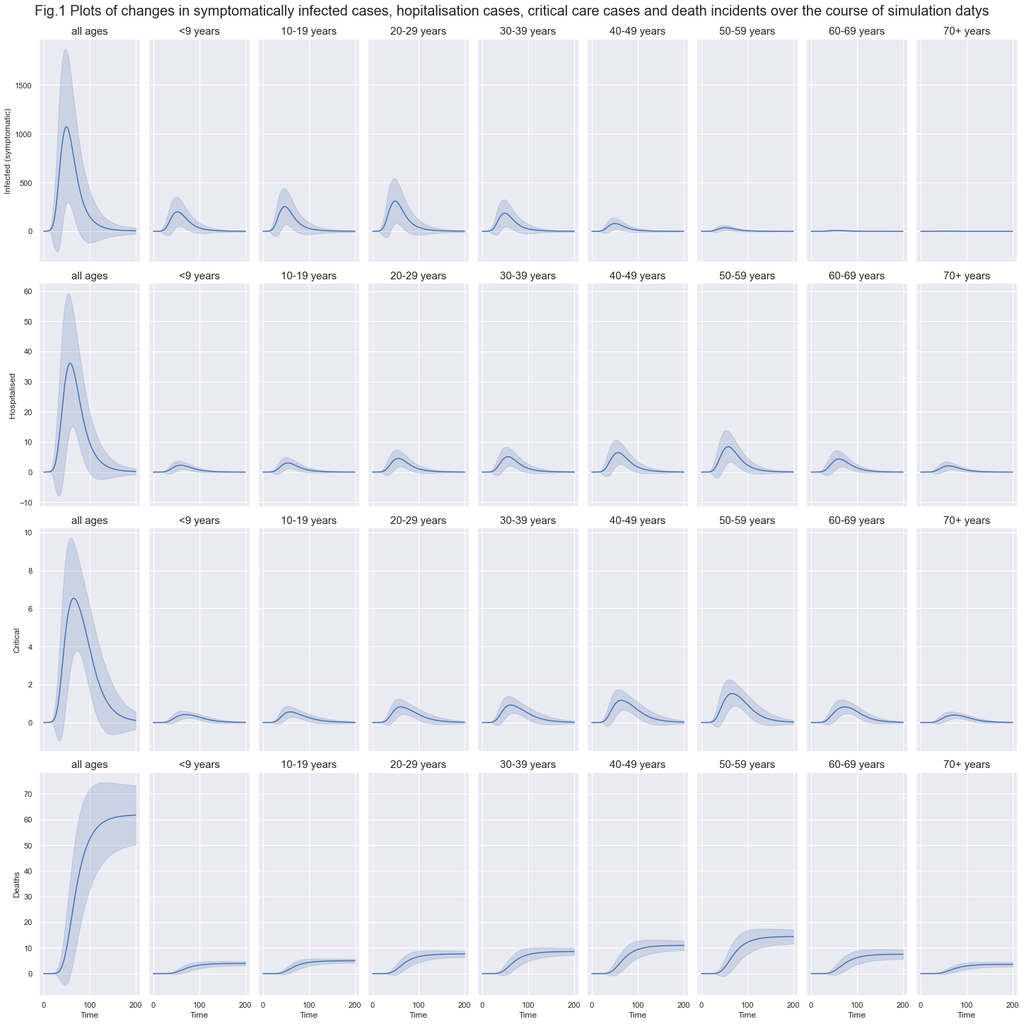

```python
plot_by_age_all(baseline)
```

### 2.2 Cumulative counts of the incidences

```python
comulative_table_all=cumulative_all_table(baseline);comulative_table_all
```

Table 3. Cumulative case counts of different disease states of COVID19

| Totals | Counts |
| --- | --- |
| Symptomatic Cases | 6451-7079 |
| Hospital Person-Days | 1750-2158 |
| Critical Person-days | 433-493 |
| Deaths | 59-68 |

```python
count_table_age=cumulative_age_table(baseline);count_table_age
```

Table 4. Cumulative case counts of different disease states of COVID19 breakdown by age

|  |  | First month | First three months | First six months |
| --- | --- | --- | --- | --- |
| Symptomatic Cases | all ages | 82-918 | 6216-7070 | 6450-7079 |
|  | <9 years | 10-119 | 1158-1436 | 1241-1439 |
|  | 10-19 years | 14-152 | 753-800 | 765-800 |
|  | 20-29 years | 24-267 | 1637-1782 | 1677-1783 |
|  | 30-39 years | 17-193 | 1214-1321 | 1246-1322 |
|  | 40-49 years | 9-106 | 743-842 | 769-843 |
|  | 50-59 years | 5-59 | 472-562 | 494-563 |
|  | 60-69 years | 1-17 | 181-249 | 196-250 |
|  | 70+ years | 0-5 | 57-79 | 62-79 |
| Hospital Person-Days | all ages | 4-27 | 1302-2009 | 1750-2158 |
|  | <9 years | 0-1 | 74-130 | 113-141 |
|  | 10-19 years | 0-3 | 122-163 | 143-172 |
|  | 20-29 years | 1-4 | 176-249 | 219-265 |
|  | 30-39 years | 1-5 | 197-279 | 246-298 |
|  | 40-49 years | 1-5 | 241-358 | 316-384 |
|  | 50-59 years | 1-6 | 294-471 | 408-507 |
|  | 60-69 years | 0-2 | 129-254 | 206-274 |
|  | 70+ years | 0-1 | 62-121 | 99-131 |
| Critical Person-days | all ages | 1-3 | 257-391 | 430-491 |
|  | <9 years | 0-0 | 14-25 | 28-32 |
|  | 10-19 years | 0-0 | 25-31 | 33-40 |
|  | 20-29 years | 0-0 | 35-47 | 51-61 |
|  | 30-39 years | 0-1 | 39-53 | 58-68 |
|  | 40-49 years | 0-1 | 47-68 | 75-87 |
|  | 50-59 years | 0-1 | 58-92 | 101-115 |
|  | 60-69 years | 0-0 | 25-50 | 54-64 |
|  | 70+ years | 0-0 | 12-24 | 26-31 |
| Deaths | all ages | 0-0 | 38-63 | 59-68 |
|  | <9 years | 0-0 | 2-4 | 4-4 |
|  | 10-19 years | 0-0 | 4-5 | 5-5 |
|  | 20-29 years | 0-0 | 5-8 | 8-8 |
|  | 30-39 years | 0-0 | 6-9 | 9-9 |
|  | 40-49 years | 0-0 | 7-11 | 11-12 |
|  | 50-59 years | 0-0 | 9-15 | 14-16 |
|  | 60-69 years | 0-0 | 4-8 | 7-9 |
|  | 70+ years | 0-0 | 2-4 | 3-4 |